# Recorded Noise at Monitored Melbourne Locations

What a sparse sensor network can reveal and where the evidence stops

Sandhya Erland Chandrasekar

Xinlei Luo

Chen Liu

## Why this matters beyond one dataset

How can a city learn from sensor data without claiming more than the network can support?

We use Melbourne’s recorded **Noise** values to ask:

- When do values change?
- How do monitored sites differ?
- Do nearby activities give a stable explanation?

## What the sensor data represent

[figure not shown]

Example of fixed monitoring equipment supplied by the project team.

- Fixed equipment records values at selected locations.
- The source provides repeated observations at roughly **15-minute intervals**.
- The measured field is named **Noise** in the dataset.
- We compare those repeated values across time and place.

The exact model, physical unit and calibration still need authoritative confirmation.

## The evidence boundary comes first

### What we can say

- Results describe monitored locations.
- Time and site differences are observable.
- Contextual links can be explored.

### What we cannot say

- The physical unit is unconfirmed.
- Calibration and mounting are unknown.
- The network is not city-wide.
- Association is not causation.

Every result is framed as **recorded Noise in dataset units**.

## A defensible analytical sample

**975,550**

raw records

**893,959**

finite values

**11 of 12**

usable sensors

**2022–2026**

observed period

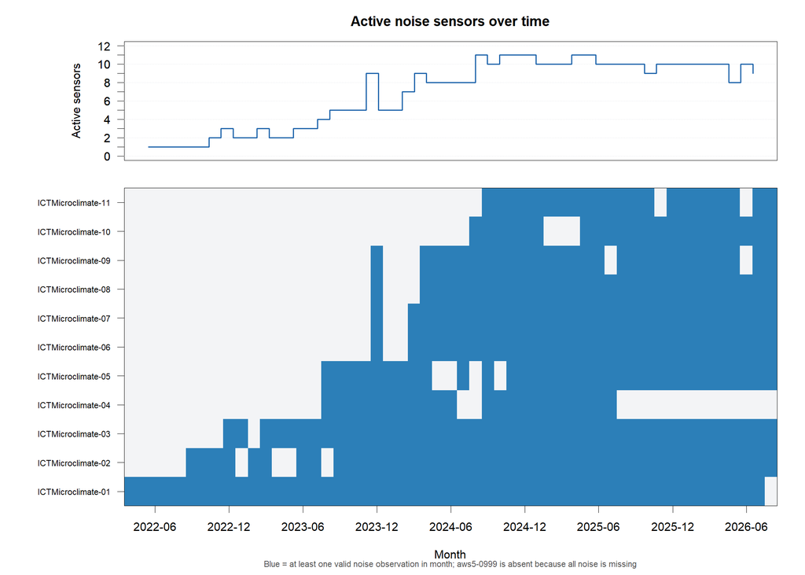

Sensor availability changes over time.

**Decision:** retain recorded zeros in the primary analysis and exclude them only in a sensitivity check.

## Linking three data systems

**Noise sensors** → **projected 250/500/1,000 m buffers** → **pedestrian counters and hospitality records**

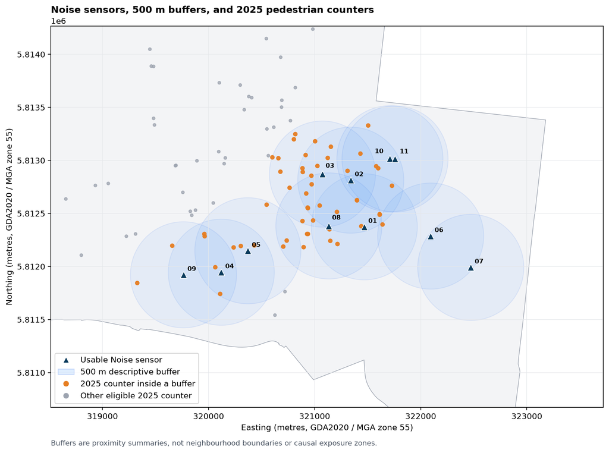

### Design choices

- Primary distance: **500 m**.
- Sensitivity: **250 and 1,000 m**.
- Pedestrian activity: **2025**.
- Hospitality context: **2024**.

Buffers describe proximity, not causal exposure.

## The clearest finding is a daily cycle

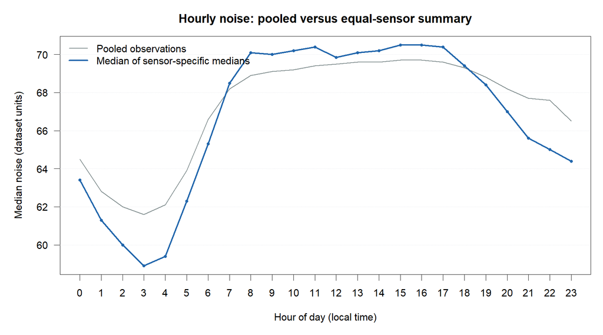

Pooled and equal-sensor hourly summaries.

Values are lowest around **03:00** and highest around **15:00–16:00**. The shape remains after giving every sensor equal weight.

## One line still hides site differences

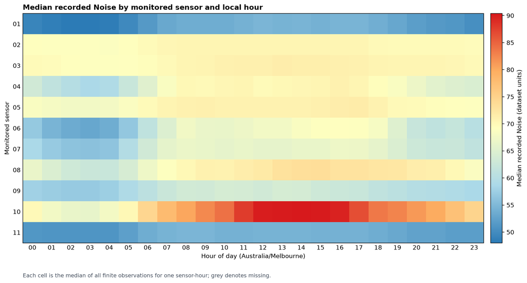

Sensor-by-hour heatmap.

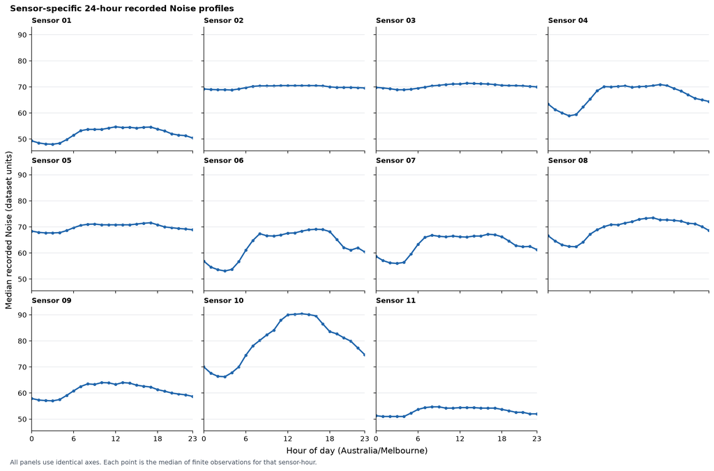

Hourly profiles on common axes.

- Site medians range from **52.3 to 81.1** dataset units.
- Sensors 02 and 03 are comparatively flat; sensor 10 rises most strongly.

**Boundary:** location, calibration, mounting, siting and observation period remain mixed together.

## Pedestrian activity does not give a stable answer

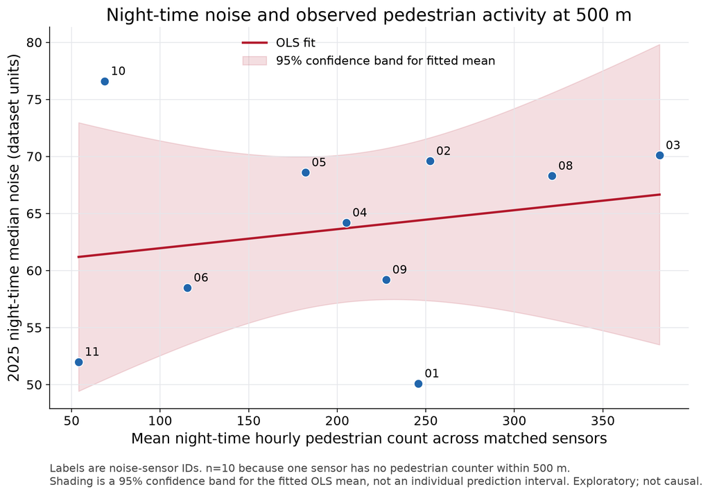

**Spearman’s rho = 0.248**  
**Permutation p-value = 0.494**  
**n = 10** at 500 m

**Stability checks**

- Leave one site out: **0.067 to 0.583**.
- Across buffers: **−0.168 to 0.618**.

**Interpretation:** no stable simple association for this measure and sample.

The shaded area is a **95% confidence band for the fitted average line**. It is not a range for individual sites.

## The original hospitality screen stayed frozen

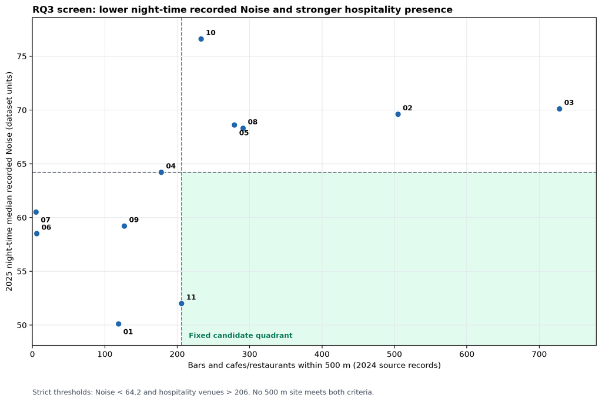

Below **64.2** and above **206** hospitality venues: **0 candidates at 500 m**.

We chose the thresholds first and did not move them after seeing the result.

## The follow-up uses all of the rankings

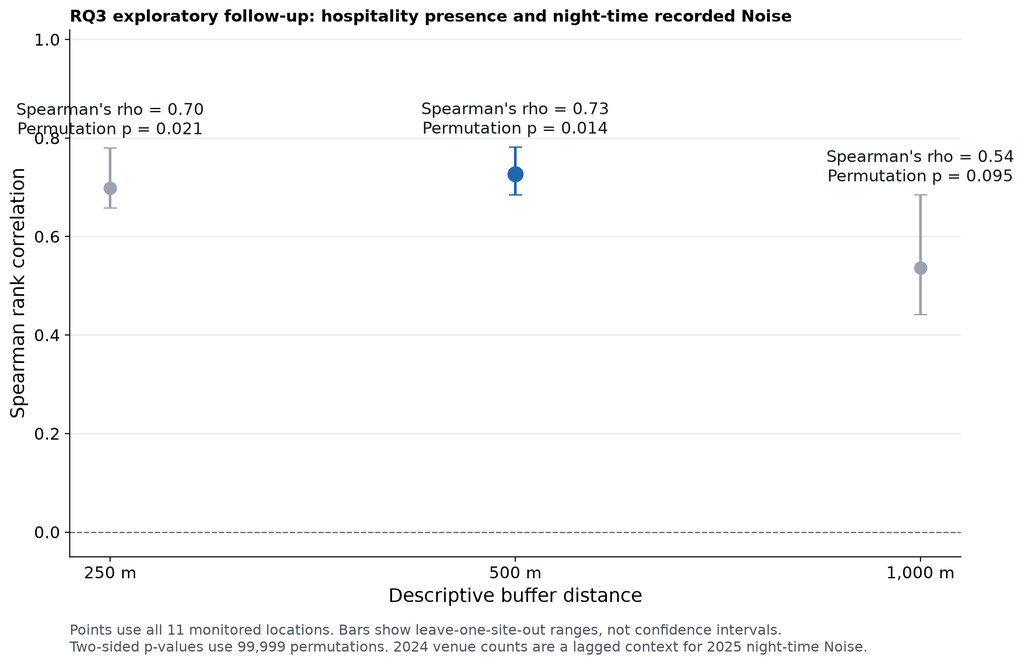

500 m: **Spearman’s rho = 0.727** · **Permutation p-value = 0.014** · **n = 11**

The bars are leave-one-site-out ranges, **not confidence intervals**. The result is post-screen, exploratory and non-causal.

## Methods matched to a small sample

### What we used

- Medians
- Equal-sensor aggregation
- Spearman rank correlation
- 99,999-draw permutation tests
- Leave-one-site-out checks
- Three buffer distances

**Permutation in plain language:** keep the context ranks fixed, shuffle the **Noise ranks across sensor sites**, and compare the shuffled correlations with the observed one.

### What this tests

- Unequal sensor coverage
- Strong distributional assumptions
- Dependence on one location
- Dependence on one buffer
- Stability, not causal effect

## What we learned—and where the evidence stops

1. A clear daily cycle appears across monitored sensors.
2. Sites differ in level and hourly shape.
3. The pedestrian result is unstable across reasonable checks.
4. The frozen hospitality screen selects no 500 m candidate.
5. A separate continuous follow-up is positive but exploratory.

Success means a reproducible and well-bounded answer. It does not mean a city-wide map, a causal model or a physical exposure measure.

Sparse sensor data can guide better questions—if the evidence boundary stays visible.

### Questions?

# Backup slides

## Seasonal sensitivity

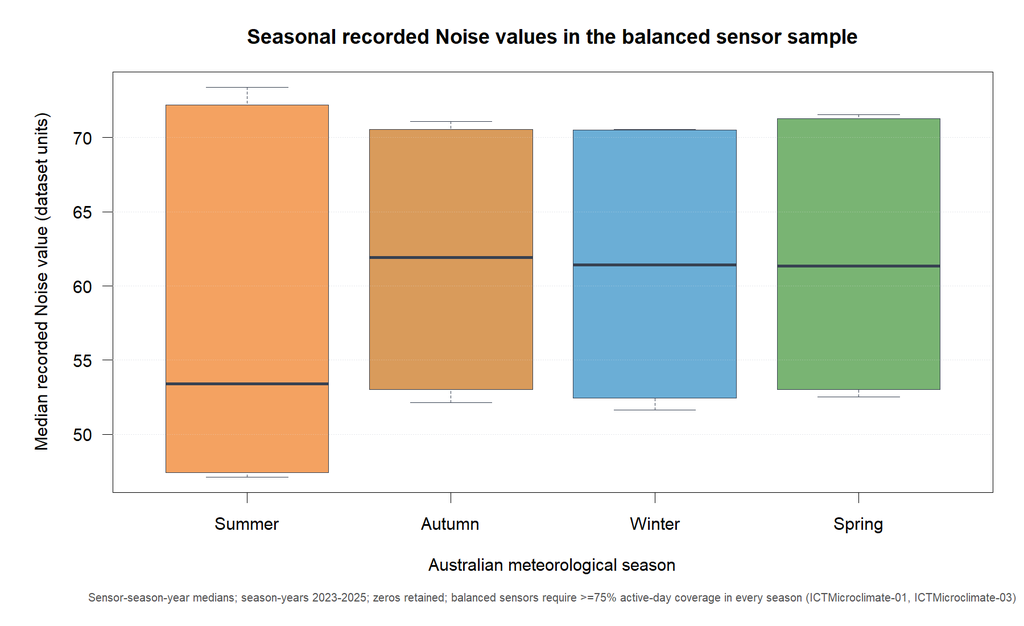

Balanced sensor-season-year distributions.

Only sensors 01 and 03 meet the 75% active-day rule in every pooled season. Seasonal ordering is therefore composition-sensitive.

## Pedestrian buffer sensitivity

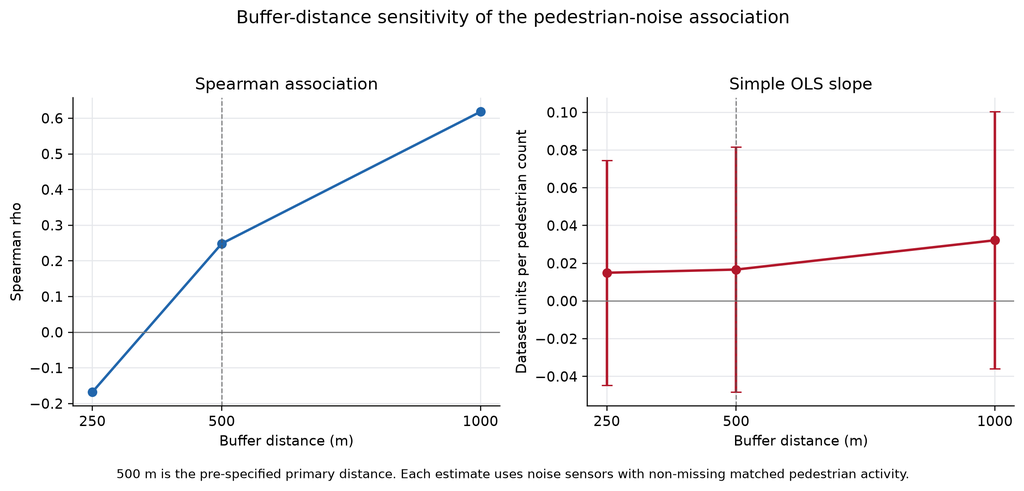

Pedestrian association estimates across buffers.

The buffer results reuse the same Noise sites with changing counter sets. They are sensitivity checks, not independent samples.

## Reproducible workflow

```bash
python analysis/run_pipeline.py --check
python analysis/run_pipeline.py --run --overwrite
quarto render presentation/final_presentation.qmd
```

The pipeline validates pinned software, six source snapshots and checksums, required scripts, spatial joins, processed tables, figures and statistical outputs.